# Statistiek I - Lab session 7

# 10 Exercise 10

```r
# Is there a relation between education level and playing an instrument for students that do not speak Frisian?

# Cross table of bl_edu and instruments for not Frisian speakers
(counts <- table(full[full$spk_frisian == "N", ]$instrument, full[full$spk_frisian == "N", ]$edu_level))
```

```
##
##     HAVO VWO HBO
##   Y   22 177  39
##   N   25 102  40
```

```r
# Expected frequencies
chisq.test(counts)$expected
```

```
##
##         HAVO      VWO      HBO
##   Y 27.61975 163.9556 46.42469
##   N 19.38025 115.0444 32.57531
```

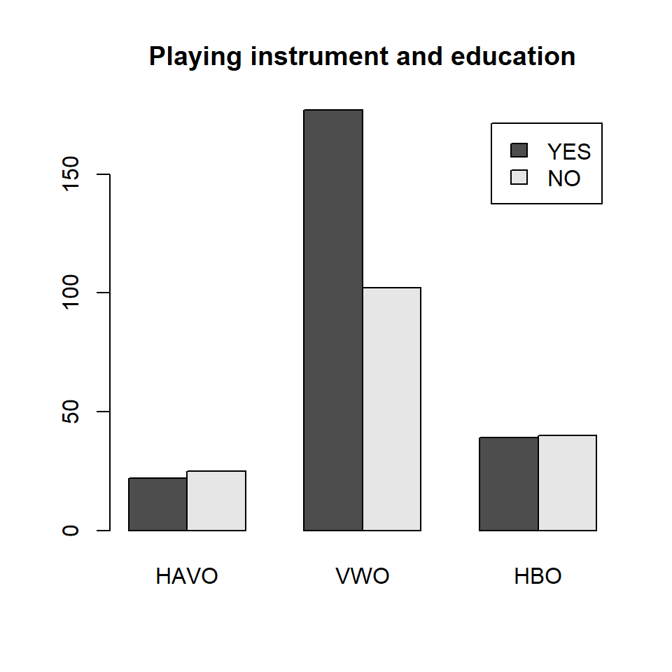

```r
# Visualization
barplot(counts, legend = c("YES", "NO"), beside = TRUE, main = "Playing instrument and education")
```

```r
# Fisher's exact test
fisher.test(counts)
```

```
##
##  Fisher's Exact Test for Count Data
##
## data:  counts
## p-value = 0.01657
## alternative hypothesis: two.sided
```

```r
# Effect size
assocstats(counts)
```

```
##                     X^2 df P(> X^2)
## Likelihood Ratio 8.1042  2 0.017386
## Pearson          8.1696  2 0.016826
##
## Phi-Coefficient   : NA
## Contingency Coeff.: 0.141
## Cramer's V        : 0.142
```

```r
# Observed frequencies
chisq.test(counts)$observed
```

```
##
##     HAVO VWO HBO
##   Y   22 177  39
##   N   25 102  40
```

```r
# z-scored differences
chisq.test(counts)$stdres
```

```
##
##          HAVO       VWO       HBO
##   Y -1.771180  2.844291 -1.891437
##   N  1.771180 -2.844291  1.891437
```

I tested whether the education level (three levels: HAVO, VWO, HBO) and whether or not they play an instrument (two levels: YES, NO) is related for students that do not speak Frisian (with **α-level = 0.05**). Our hypotheses were: **H0: Education level and instrument are independent for non-Frisian speakers** and **Ha: Education level and instrument are dependent for non-Frisian speakers**. In our **sample of 405 students** of the Statistiek 1 course, we obtained the participants their instrument and education data via an online questionnaire. The first tables shows their relation and the figure shows a barplot visualizing the results of the table. As both variables are nominal, and the expected frequency of each combination was greater than 5, we assessed the dependence of the two variables using a **χ2 test: χ2(2) = 8.1696, p = 0.01683**. As the p-value was lower than the α-level, the result was significant. We therefore **accept the alternative hypothesis and reject the null hypothesis** meaning that education level and playing an instrument are dependent for non-Frisian speakers. The difference from the expected distribution was greatest for students who play an instrument and were VWO educated. There were more students for those than expected. The **effect size was small (Cramer’s V = 0.142)**.